# Kalp Krizi Verisi Üzerinde Tanımlayıcı İstatistikler ve Görselleştirme

GitHub: Ozgurnrttn

# 1 Ugulama Kalp Krizi Veri Seti İle İlgili Uygulamalar

Kalp Krizi veri seti veri seti uzerinde veri temizleme, veri duzenleme, gerekli gorulen fonksiyonlarin veri seti uzerinde kullanilmasi, tanimsal istatistikleri elde etme, gorsellestirme uygulanmistir.

Veri Seti kaggle uzerinden https://www.kaggle.com/ronitf/heart-disease-uci linki ile alinmistir.

**Verini Tanımı**

| Değişken | Türkçe İsim | Bilgi |
| --- | --- | --- |
| Age | Yaş | Scaler |
| Sex | Cinsiyet | Nominal (0= Kadın, 1=Erkek) |
| Cp | Göğüs Ağrısı Tipi | Ordinla (0= Tipik Anjina, 1=Atipik Anjina, 2=Non-Anginal Pain, 3=Asemptomatik) |
| Trestbps | Kan Basıncı | Scaler |
| Chol | Kolesterol | Scaler |
| Fbs | Kan Şekeri | Scaler |
| Restecg | Elektrokardiyografik Sonuçları | Nominal |
| Thalach | En Yüksek Kalp Atış Hızı | Scaler |
| Exang | Anjina | Nominal (0=Yok, 1=Var) |
| Oldpeak | Oldpeak | Scaler |
| Slope | ST segmentinin Eğimi | Nominal |
| Ca | Renklendilmiş Damar Sayısı | Scaler |
| Thal Thal | Nominal |  |
| Target | Hedef | Nominal |

```r
library("tidyr")
library("tidyverse")
```

```r
library("dplyr")
library("ggplot2")
library("readr")
library("rstatix")
library("pastecs")
library("readr")
```

```r
heart <- read_csv("C:/Users/oztur/OneDrive/Masaüstü/heart.csv")
heart$cp<-factor(heart$cp,levels = c(0,1,2,3),labels=c("Tipik Anjina","Atipik Anjina","Non-Anginal Pain"," Asemptomatik"))
heart$sex<-factor(heart$sex,levels = c(0,1),labels=c("Kadın","Erkek"))
heart$exang<-factor(heart$exang,levels = c(0,1),labels=c("No","Yes"))
```

```r
as_tibble(heart)
```

| age | sex | cp | trestbps | chol | fbs | restecg | thalach | exang | oldpeak | slope | ca | thal | target |
| --- | --- | --- | --- | --- | --- | --- | --- | --- | --- | --- | --- | --- | --- |
| 63 | Erkek | Asemptomatik | 145 | 233 | 1 | 0 | 150 | No | 2.3 | 0 | 0 | 1 | 1 |
| 37 | Erkek | Non-Anginal Pain | 130 | 250 | 0 | 1 | 187 | No | 3.5 | 0 | 0 | 2 | 1 |
| 41 | Kadin | Atipik Anjina | 130 | 204 | 0 | 0 | 172 | No | 1.4 | 2 | 0 | 2 | 1 |
| 56 | Erkek | Atipik Anjina | 120 | 236 | 0 | 1 | 178 | No | 0.8 | 2 | 0 | 2 | 1 |
| 57 | Kadin | Tipik Anjina | 120 | 354 | 0 | 1 | 163 | Yes | 0.6 | 2 | 0 | 2 | 1 |
| 57 | Erkek | Tipik Anjina | 140 | 192 | 0 | 1 | 148 | No | 0.4 | 1 | 0 | 1 | 1 |
| 56 | Kadin | Atipik Anjina | 140 | 294 | 0 | 0 | 153 | No | 1.3 | 1 | 0 | 2 | 1 |
| 44 | Erkek | Atipik Anjina | 120 | 263 | 0 | 1 | 173 | No | 0.0 | 2 | 0 | 3 | 1 |
| 52 | Erkek | Non-Anginal Pain | 172 | 199 | 1 | 1 | 162 | No | 0.5 | 2 | 0 | 3 | 1 |
| 57 | Erkek | Non-Anginal Pain | 150 | 168 | 0 | 1 | 174 | No | 1.6 | 2 | 0 | 2 | 1 |

[output cut: 293 more lines]

# 2 Tanımsal İstatistikler

```r
pastecs::stat.desc(heart[,c(1,5:8,10,12)])
```

|  | age | chol | fbs | restecg | thalach | oldpeak | ca |
| --- | --- | --- | --- | --- | --- | --- | --- |
| nbr.val | 3.030000e+02 | 3.030000e+02 | 303.00000000 | 303.00000000 | 3.030000e+02 | 303.00000000 | 303.0000000 |
| nbr.null | 0.000000e+00 | 0.000000e+00 | 258.00000000 | 147.00000000 | 0.000000e+00 | 99.00000000 | 175.0000000 |
| nbr.na | 0.000000e+00 | 0.000000e+00 | 0.00000000 | 0.00000000 | 0.000000e+00 | 0.00000000 | 0.0000000 |
| min | 2.900000e+01 | 1.260000e+02 | 0.00000000 | 0.00000000 | 7.100000e+01 | 0.00000000 | 0.0000000 |
| max | 7.700000e+01 | 5.640000e+02 | 1.00000000 | 2.00000000 | 2.020000e+02 | 6.20000000 | 4.0000000 |
| range | 4.800000e+01 | 4.380000e+02 | 1.00000000 | 2.00000000 | 1.310000e+02 | 6.20000000 | 4.0000000 |
| sum | 1.647300e+04 | 7.461800e+04 | 45.00000000 | 160.00000000 | 4.534300e+04 | 315.00000000 | 221.0000000 |
| median | 5.500000e+01 | 2.400000e+02 | 0.00000000 | 1.00000000 | 1.530000e+02 | 0.80000000 | 0.0000000 |
| mean | 5.436634e+01 | 2.462640e+02 | 0.14851485 | 0.52805281 | 1.496469e+02 | 1.03960396 | 0.7293729 |
| SE.mean | 5.217531e-01 | 2.977599e+00 | 0.02046303 | 0.03020984 | 1.315867e+00 | 0.06670202 | 0.0587472 |

[output cut: 4 more lines]

Degiskenlerin istatistikleri

```r
glimpse(heart)
```

```
## Rows: 303
## Columns: 14
## $ age      <dbl> 63, 37, 41, 56, 57, 57, 56, 44, 52, 57, 54, 48, 49, 64, 58...
## $ sex      <fct> Erkek, Erkek, Kadin, Erkek, Kadin, Erkek, Kadin, Erkek, Er...
## $ cp       <fct>  Asemptomatik, Non-Anginal Pain, Atipik Anjina, Atipik Anj...
## $ trestbps <dbl> 145, 130, 130, 120, 120, 140, 140, 120, 172, 150, 140, 130...
## $ chol     <dbl> 233, 250, 204, 236, 354, 192, 294, 263, 199, 168, 239, 275...
## $ fbs      <dbl> 1, 0, 0, 0, 0, 0, 0, 0, 1, 0, 0, 0, 0, 0, 1, 0, 0, 0, 0, 0...
## $ restecg  <dbl> 0, 1, 0, 1, 1, 1, 0, 1, 1, 1, 1, 1, 1, 0, 0, 1, 1, 1, 1, 1...
## $ thalach  <dbl> 150, 187, 172, 178, 163, 148, 153, 173, 162, 174, 160, 139...
## $ exang    <fct> No, No, No, No, Yes, No, No, No, No, No, No, No, No, Yes, ...
## $ oldpeak  <dbl> 2.3, 3.5, 1.4, 0.8, 0.6, 0.4, 1.3, 0.0, 0.5, 1.6, 1.2, 0.2...
## $ slope    <dbl> 0, 0, 2, 2, 2, 1, 1, 2, 2, 2, 2, 2, 2, 1, 2, 1, 2, 0, 2, 2...
## $ ca       <dbl> 0, 0, 0, 0, 0, 0, 0, 0, 0, 0, 0, 0, 0, 0, 0, 0, 0, 0, 0, 2...
## $ thal     <dbl> 1, 2, 2, 2, 2, 1, 2, 3, 3, 2, 2, 2, 2, 2, 2, 2, 2, 2, 2, 2...
## $ target   <dbl> 1, 1, 1, 1, 1, 1, 1, 1, 1, 1, 1, 1, 1, 1, 1, 1, 1, 1, 1, 1...
```

# 3 Normallik Testi

```r
heart %>%
  dplyr::select(age, trestbps, chol, fbs, thalach, oldpeak) %>%
  mshapiro_test()
```

| statistic | p.value |
| --- | --- |
| 0.9400521 | 9.695797e-10 |

%95 Güven düzeyinde değişkenler normal dağılımdan gelmemektedir.

```r
as_tibble(is.na(heart))
```

| age | sex | cp | trestbps | chol | fbs | restecg | thalach | exang | oldpeak | slope | ca | thal | target |
| --- | --- | --- | --- | --- | --- | --- | --- | --- | --- | --- | --- | --- | --- |
| FALSE | FALSE | FALSE | FALSE | FALSE | FALSE | FALSE | FALSE | FALSE | FALSE | FALSE | FALSE | FALSE | FALSE |
| FALSE | FALSE | FALSE | FALSE | FALSE | FALSE | FALSE | FALSE | FALSE | FALSE | FALSE | FALSE | FALSE | FALSE |
| FALSE | FALSE | FALSE | FALSE | FALSE | FALSE | FALSE | FALSE | FALSE | FALSE | FALSE | FALSE | FALSE | FALSE |
| FALSE | FALSE | FALSE | FALSE | FALSE | FALSE | FALSE | FALSE | FALSE | FALSE | FALSE | FALSE | FALSE | FALSE |
| FALSE | FALSE | FALSE | FALSE | FALSE | FALSE | FALSE | FALSE | FALSE | FALSE | FALSE | FALSE | FALSE | FALSE |
| FALSE | FALSE | FALSE | FALSE | FALSE | FALSE | FALSE | FALSE | FALSE | FALSE | FALSE | FALSE | FALSE | FALSE |
| FALSE | FALSE | FALSE | FALSE | FALSE | FALSE | FALSE | FALSE | FALSE | FALSE | FALSE | FALSE | FALSE | FALSE |
| FALSE | FALSE | FALSE | FALSE | FALSE | FALSE | FALSE | FALSE | FALSE | FALSE | FALSE | FALSE | FALSE | FALSE |
| FALSE | FALSE | FALSE | FALSE | FALSE | FALSE | FALSE | FALSE | FALSE | FALSE | FALSE | FALSE | FALSE | FALSE |
| FALSE | FALSE | FALSE | FALSE | FALSE | FALSE | FALSE | FALSE | FALSE | FALSE | FALSE | FALSE | FALSE | FALSE |

[output cut: 293 more lines]

Veride missing values yoktur.

# 4 Dplyr Fonksiyonu ile işlemler

### 4.0.1 Select

Heart verisiden göğüs ağrısı tipi, kan basıncı, kan şekeri, cp, trestbps, chol, fbs ve restecg değişkenlerini getir?

```r
select(heart,cp:restecg)
```

| cp | trestbps | chol | fbs | restecg |
| --- | --- | --- | --- | --- |
| Asemptomatik | 145 | 233 | 1 | 0 |
| Non-Anginal Pain | 130 | 250 | 0 | 1 |
| Atipik Anjina | 130 | 204 | 0 | 0 |
| Atipik Anjina | 120 | 236 | 0 | 1 |
| Tipik Anjina | 120 | 354 | 0 | 1 |
| Tipik Anjina | 140 | 192 | 0 | 1 |
| Atipik Anjina | 140 | 294 | 0 | 0 |
| Atipik Anjina | 120 | 263 | 0 | 1 |
| Non-Anginal Pain | 172 | 199 | 1 | 1 |
| Non-Anginal Pain | 150 | 168 | 0 | 1 |

[output cut: 293 more lines]

Heart verisiden göğüs ağrısı tipi, kan basıncı, kolesterol, kan şekeri ve elektrokardiyografik sonuçları değişkenleri dışındaki değişkenleri getir?

```r
select(heart,-(cp:restecg))
```

| age | sex | thalach | exang | oldpeak | slope | ca | thal | target |
| --- | --- | --- | --- | --- | --- | --- | --- | --- |
| 63 | Erkek | 150 | No | 2.3 | 0 | 0 | 1 | 1 |
| 37 | Erkek | 187 | No | 3.5 | 0 | 0 | 2 | 1 |
| 41 | Kadin | 172 | No | 1.4 | 2 | 0 | 2 | 1 |
| 56 | Erkek | 178 | No | 0.8 | 2 | 0 | 2 | 1 |
| 57 | Kadin | 163 | Yes | 0.6 | 2 | 0 | 2 | 1 |
| 57 | Erkek | 148 | No | 0.4 | 1 | 0 | 1 | 1 |
| 56 | Kadin | 153 | No | 1.3 | 1 | 0 | 2 | 1 |
| 44 | Erkek | 173 | No | 0.0 | 2 | 0 | 3 | 1 |
| 52 | Erkek | 162 | No | 0.5 | 2 | 0 | 3 | 1 |
| 57 | Erkek | 174 | No | 1.6 | 2 | 0 | 2 | 1 |

[output cut: 293 more lines]

## 4.1 Filter

```r
filter(heart, cp %in% c("Tipik Anjina","Asemptomatik"))
```

| age | sex | cp | trestbps | chol | fbs | restecg | thalach | exang | oldpeak | slope | ca | thal | target |
| --- | --- | --- | --- | --- | --- | --- | --- | --- | --- | --- | --- | --- | --- |
| 57 | Kadin | Tipik Anjina | 120 | 354 | 0 | 1 | 163 | Yes | 0.6 | 2 | 0 | 2 | 1 |
| 57 | Erkek | Tipik Anjina | 140 | 192 | 0 | 1 | 148 | No | 0.4 | 1 | 0 | 1 | 1 |
| 54 | Erkek | Tipik Anjina | 140 | 239 | 0 | 1 | 160 | No | 1.2 | 2 | 0 | 2 | 1 |
| 43 | Erkek | Tipik Anjina | 150 | 247 | 0 | 1 | 171 | No | 1.5 | 2 | 0 | 2 | 1 |
| 59 | Erkek | Tipik Anjina | 135 | 234 | 0 | 1 | 161 | No | 0.5 | 1 | 0 | 3 | 1 |
| 42 | Erkek | Tipik Anjina | 140 | 226 | 0 | 1 | 178 | No | 0.0 | 2 | 0 | 2 | 1 |
| 65 | Erkek | Tipik Anjina | 120 | 177 | 0 | 1 | 140 | No | 0.4 | 2 | 0 | 3 | 1 |
| 45 | Erkek | Tipik Anjina | 104 | 208 | 0 | 0 | 148 | Yes | 3.0 | 1 | 0 | 2 | 1 |
| 53 | Kadin | Tipik Anjina | 130 | 264 | 0 | 0 | 143 | No | 0.4 | 1 | 0 | 2 | 1 |
| 53 | Kadin | Tipik Anjina | 138 | 234 | 0 | 0 | 160 | No | 0.0 | 2 | 0 | 2 | 1 |

[output cut: 133 more lines]

Kan basıncı 180’den az olanları ve kolesterolü 250’den fazla olanları getir getir.

```r
filter(heart, trestbps <180 & chol > 250)
```

| age | sex | cp | trestbps | chol | fbs | restecg | thalach | exang | oldpeak | slope | ca | thal | target |
| --- | --- | --- | --- | --- | --- | --- | --- | --- | --- | --- | --- | --- | --- |
| 57 | Kadin | Tipik Anjina | 120 | 354 | 0 | 1 | 163 | Yes | 0.6 | 2 | 0 | 2 | 1 |
| 56 | Kadin | Atipik Anjina | 140 | 294 | 0 | 0 | 153 | No | 1.3 | 1 | 0 | 2 | 1 |
| 44 | Erkek | Atipik Anjina | 120 | 263 | 0 | 1 | 173 | No | 0.0 | 2 | 0 | 3 | 1 |
| 48 | Kadin | Non-Anginal Pain | 130 | 275 | 0 | 1 | 139 | No | 0.2 | 2 | 0 | 2 | 1 |
| 49 | Erkek | Atipik Anjina | 130 | 266 | 0 | 1 | 171 | No | 0.6 | 2 | 0 | 2 | 1 |
| 58 | Kadin | Asemptomatik | 150 | 283 | 1 | 0 | 162 | No | 1.0 | 2 | 0 | 2 | 1 |
| 58 | Kadin | Non-Anginal Pain | 120 | 340 | 0 | 1 | 172 | No | 0.0 | 2 | 0 | 2 | 1 |
| 71 | Kadin | Atipik Anjina | 160 | 302 | 0 | 1 | 162 | No | 0.4 | 2 | 2 | 2 | 1 |
| 65 | Kadin | Non-Anginal Pain | 140 | 417 | 1 | 0 | 157 | No | 0.8 | 2 | 1 | 2 | 1 |
| 54 | Erkek | Non-Anginal Pain | 125 | 273 | 0 | 0 | 152 | No | 0.5 | 0 | 1 | 2 | 1 |

[output cut: 111 more lines]

## 4.2 Arrange

Heart verisini kan sekerine gore kucukten buyuge sırala?

```r
arrange(heart, fbs)
```

| age | sex | cp | trestbps | chol | fbs | restecg | thalach | exang | oldpeak | slope | ca | thal | target |
| --- | --- | --- | --- | --- | --- | --- | --- | --- | --- | --- | --- | --- | --- |
| 37 | Erkek | Non-Anginal Pain | 130 | 250 | 0 | 1 | 187 | No | 3.5 | 0 | 0 | 2 | 1 |
| 41 | Kadin | Atipik Anjina | 130 | 204 | 0 | 0 | 172 | No | 1.4 | 2 | 0 | 2 | 1 |
| 56 | Erkek | Atipik Anjina | 120 | 236 | 0 | 1 | 178 | No | 0.8 | 2 | 0 | 2 | 1 |
| 57 | Kadin | Tipik Anjina | 120 | 354 | 0 | 1 | 163 | Yes | 0.6 | 2 | 0 | 2 | 1 |
| 57 | Erkek | Tipik Anjina | 140 | 192 | 0 | 1 | 148 | No | 0.4 | 1 | 0 | 1 | 1 |
| 56 | Kadin | Atipik Anjina | 140 | 294 | 0 | 0 | 153 | No | 1.3 | 1 | 0 | 2 | 1 |
| 44 | Erkek | Atipik Anjina | 120 | 263 | 0 | 1 | 173 | No | 0.0 | 2 | 0 | 3 | 1 |
| 57 | Erkek | Non-Anginal Pain | 150 | 168 | 0 | 1 | 174 | No | 1.6 | 2 | 0 | 2 | 1 |
| 54 | Erkek | Tipik Anjina | 140 | 239 | 0 | 1 | 160 | No | 1.2 | 2 | 0 | 2 | 1 |
| 48 | Kadin | Non-Anginal Pain | 130 | 275 | 0 | 1 | 139 | No | 0.2 | 2 | 0 | 2 | 1 |

[output cut: 293 more lines]

Heart verisinde yaş, kan basıncı,kolesterol ve oldpeak değişkenlerini oldpeak değişkenine göre küçükten büyüğe sırala?

```r
arrange(select(heart,age, trestbps, chol, oldpeak), oldpeak)
```

| age | trestbps | chol | oldpeak |
| --- | --- | --- | --- |
| 44 | 120 | 263 | 0.0 |
| 58 | 120 | 340 | 0.0 |
| 42 | 140 | 226 | 0.0 |
| 41 | 105 | 198 | 0.0 |
| 44 | 130 | 219 | 0.0 |
| 54 | 135 | 304 | 0.0 |
| 39 | 140 | 321 | 0.0 |
| 44 | 140 | 235 | 0.0 |
| 47 | 138 | 257 | 0.0 |
| 53 | 128 | 216 | 0.0 |

[output cut: 293 more lines]

```r
arrange(select(heart,age, trestbps, chol, oldpeak), desc(oldpeak))
```

| age | trestbps | chol | oldpeak |
| --- | --- | --- | --- |
| 62 | 160 | 164 | 6.2 |
| 55 | 140 | 217 | 5.6 |
| 58 | 114 | 318 | 4.4 |
| 59 | 178 | 270 | 4.2 |
| 51 | 140 | 298 | 4.2 |
| 63 | 150 | 407 | 4.0 |
| 56 | 200 | 288 | 4.0 |
| 63 | 140 | 187 | 4.0 |
| 38 | 120 | 231 | 3.8 |
| 62 | 140 | 268 | 3.6 |

[output cut: 293 more lines]

## 4.3 Summarise

Heart verisetinin gözlem sayısı, cinsiyet, göğüüs ağrısı tipi ve anjinanın kategori sayilarini ile ortalama yaş ve kan şekerinin ortalamasını bulununz

```r
summarise(heart,Gozlem_Sayisi=n(),
          Sex_Destinasyonlari=n_distinct(sex),
          Cp_Destinasyonlari= n_distinct(cp),
          Exang_Destinasyonlari= n_distinct(exang),
          Ortalama_age= mean(age, na.rm = T),
          Ortalama_fbs= mean(fbs, na.rm = T))
```

| Gozlem_Sayisi | Sex_Destinasyonlari | Cp_Destinasyonlari | Exang_Destinasyonlari | Ortalama_age | Ortalama_fbs |
| --- | --- | --- | --- | --- | --- |
| 303 | 2 | 4 | 2 | 54.36634 | 0.1485149 |

## 4.4 Pipe operatoru

```r
heart %>%
  select(trestbps,thalach) %>%
  filter(trestbps< thalach) %>%
  summarise(Ortalama_Thalach= mean(thalach))
```

| Ortalama_Thalach |
| --- |
| 158.1754 |

Toplam yaşı bulunuz?

```r
heart %>% select(age) %>% sum()
```

```
## [1] 16473
```

Kadınların olanların yaşlarını bulunuz?

```r
as_tibble(heart %>% select(sex, age) %>% filter(sex=="Kadin"))
```

| sex | age |
| --- | --- |
| Kadin | 41 |
| Kadin | 57 |
| Kadin | 56 |
| Kadin | 48 |
| Kadin | 58 |
| Kadin | 50 |
| Kadin | 58 |
| Kadin | 66 |
| Kadin | 69 |
| Kadin | 71 |

[output cut: 86 more lines]

## 4.5 Group By

Göğüs ağrısı tipi değişkenini kategorilere gore dagilimi

```r
heart %>% group_by(cp) %>% summarise(Adet=n())
```

| cp | Adet |
| --- | --- |
| Tipik Anjina | 143 |
| Atipik Anjina | 50 |
| Non-Anginal Pain | 87 |
| Asemptomatik | 23 |

Cinsiyet degiskeninin kategorilere gore dagilimi

```r
heart %>% group_by(sex) %>% summarise(Adet=n())
```

| sex | Adet |
| --- | --- |
| Kadin | 96 |
| Erkek | 207 |

Anjina degiskeninin kategorilere gore dagilimi

```r
heart %>% group_by(exang) %>% summarise(Adet=n())
```

| exang | Adet |
| --- | --- |
| No | 204 |
| Yes | 99 |

Göğüs ağrısı tipi ve cinsiyet degiskenlerini ikili dagilimi

```r
heart %>% group_by(cp, sex) %>% summarise(Adet=n())
```

| cp | sex | Adet |
| --- | --- | --- |
| Tipik Anjina | Kadin | 39 |
| Tipik Anjina | Erkek | 104 |
| Atipik Anjina | Kadin | 18 |
| Atipik Anjina | Erkek | 32 |
| Non-Anginal Pain | Kadin | 35 |
| Non-Anginal Pain | Erkek | 52 |
| Asemptomatik | Kadin | 4 |
| Asemptomatik | Erkek | 19 |

# 5 Grafikler

## 5.1 Point plot

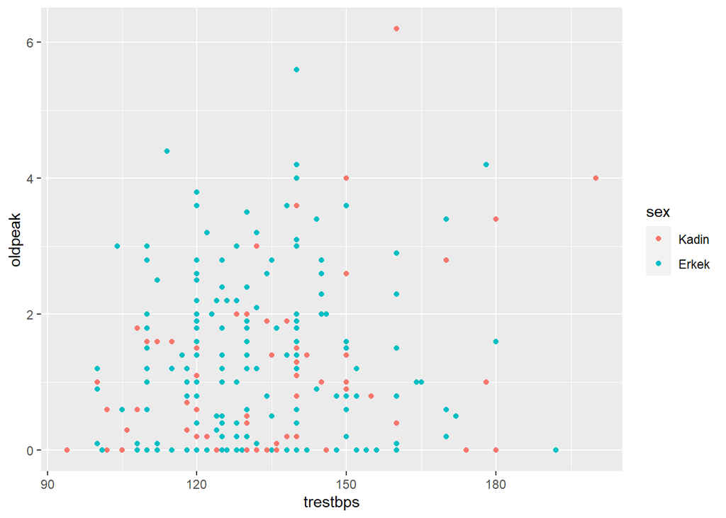

```r
ggplot(data=heart)+ geom_point(mapping = aes(x=trestbps,y= oldpeak,color=sex))
```

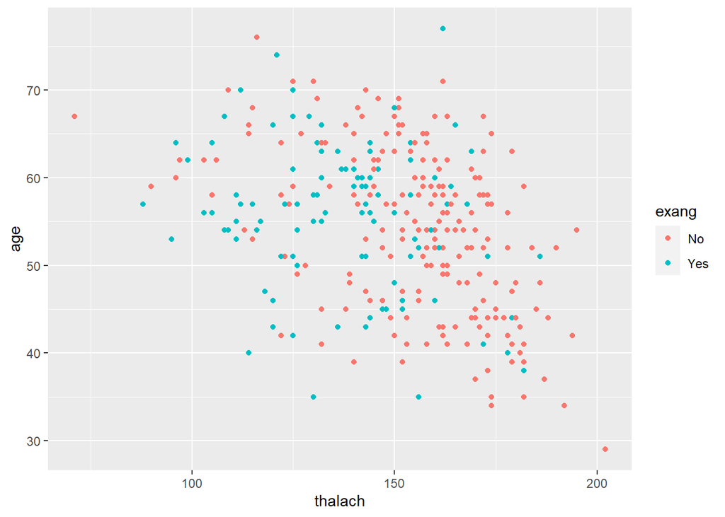

```r
attach(heart)
ggplot(data=heart)+ geom_point(mapping = aes(x=thalach,y=age,color=exang))
```

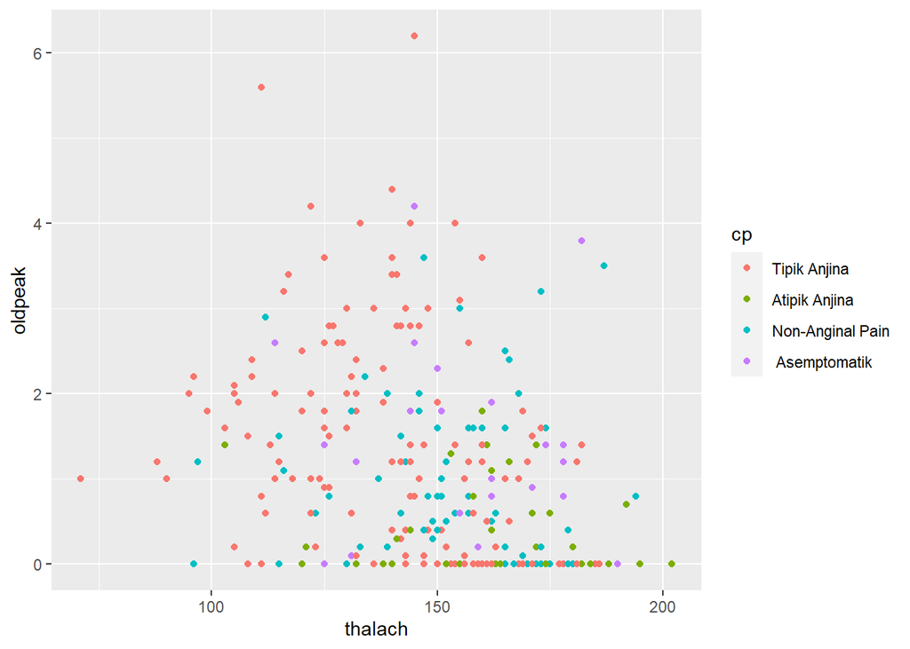

```r
ggplot(data=heart)+ geom_point(mapping = aes(x=thalach,y=oldpeak,color=cp))
```

## 5.2 Bar Plot

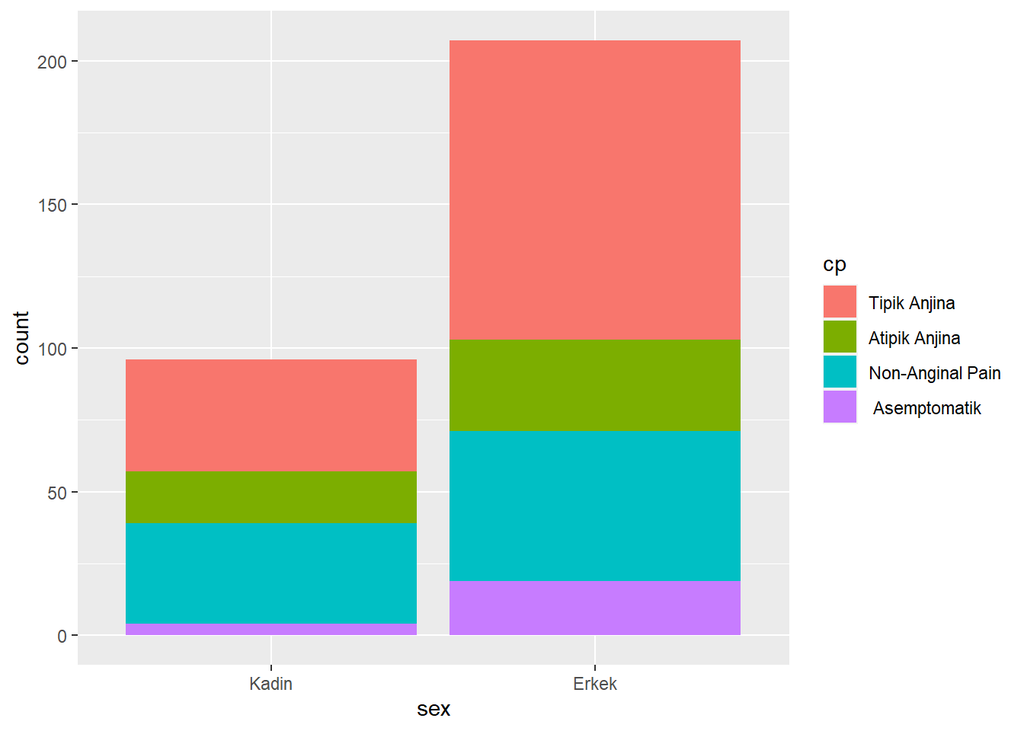

```r
ggplot(data=heart)+ geom_bar(mapping = aes(x=sex, fill=cp))
```

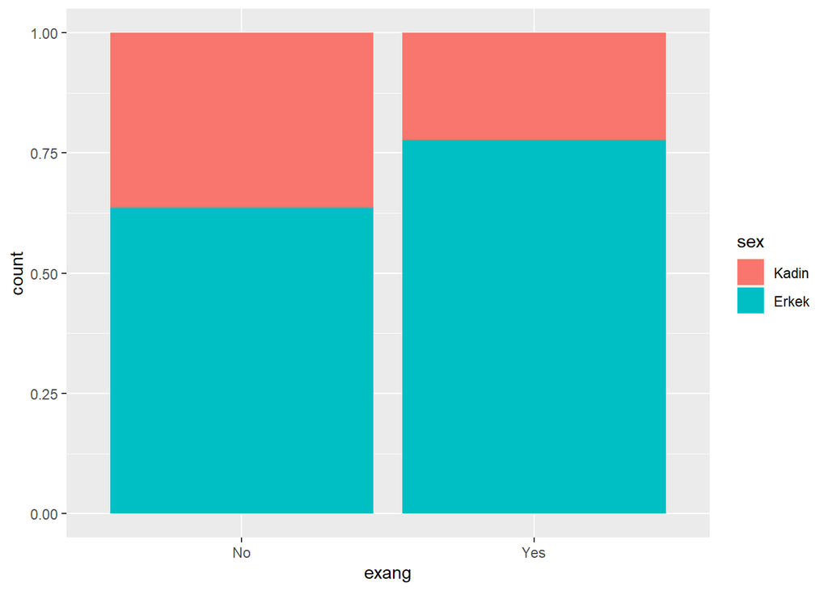

```r
ggplot(data=heart)+ geom_bar(mapping = aes(x=exang, fill=sex),position = "fill")
```

## 5.3 Box Plot

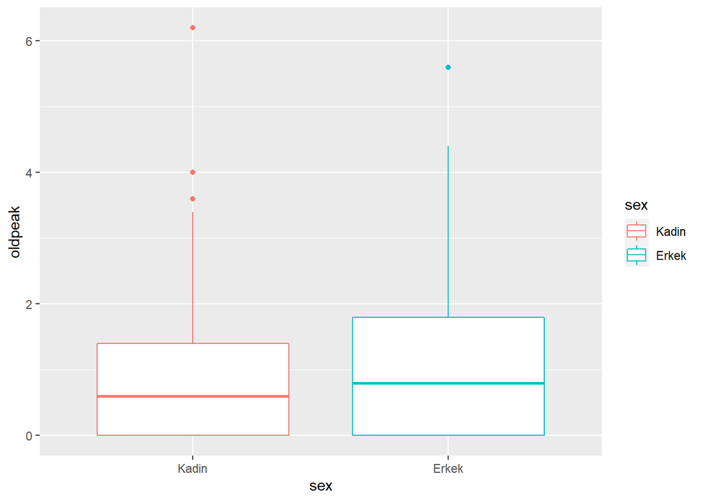

```r
ggplot(data=heart)+geom_boxplot(mapping = aes(x=sex, y=oldpeak, color=sex))
```

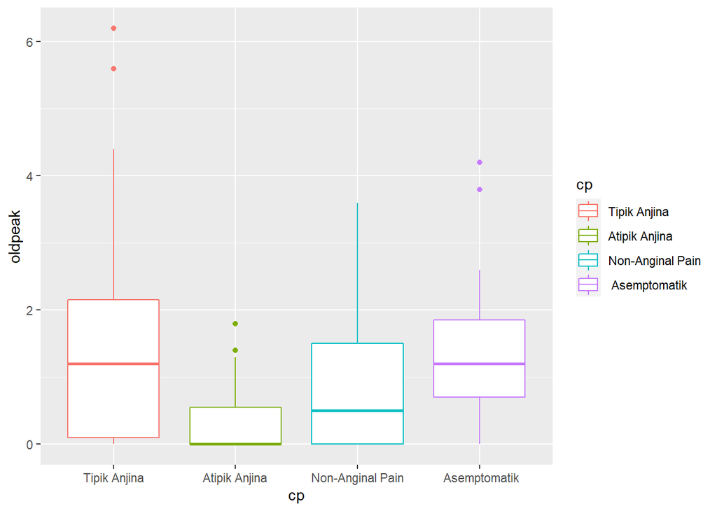

```r
ggplot(data=heart)+geom_boxplot(mapping = aes(x=cp, y=oldpeak, color=cp))
```

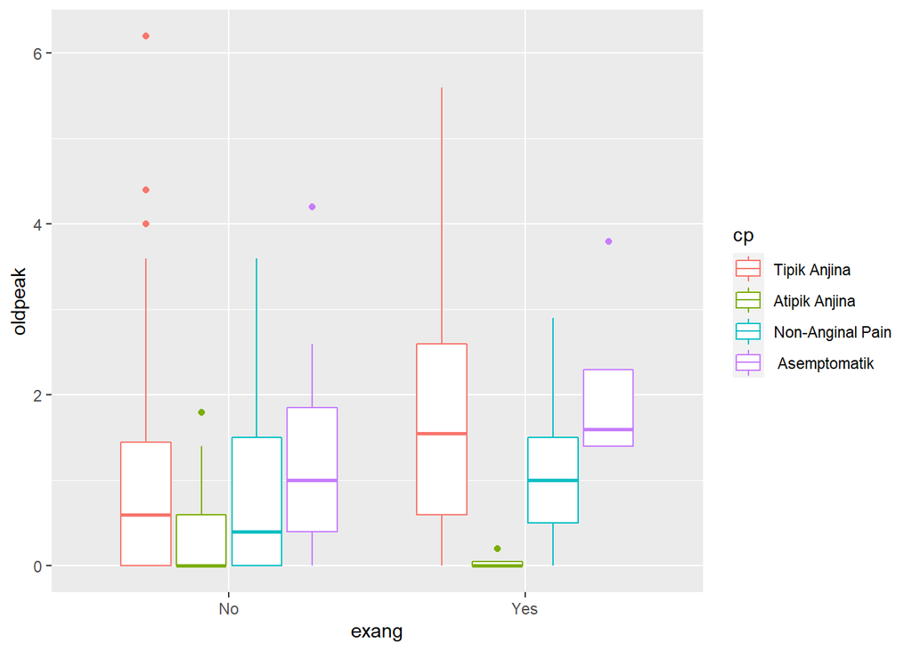

```r
ggplot(data=heart)+geom_boxplot(mapping = aes(x=exang, y=oldpeak, color=cp))
```

## 5.4 Histogram

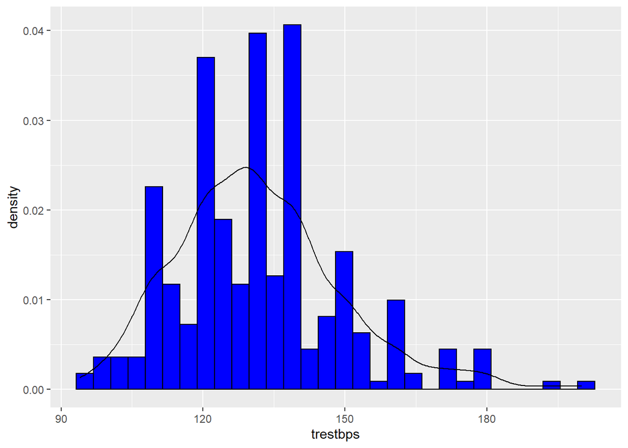

```r
ggplot(data=heart,aes(x=trestbps))+geom_histogram(aes(y=..density..),color="Black", fill="Blue")+geom_density()
```

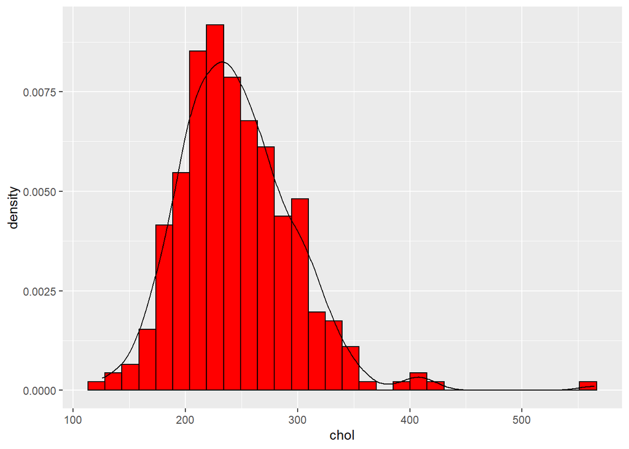

```r
ggplot(data=heart,aes(x=chol))+geom_histogram(aes(y=..density..),color="Black", fill="Red")+geom_density()
```

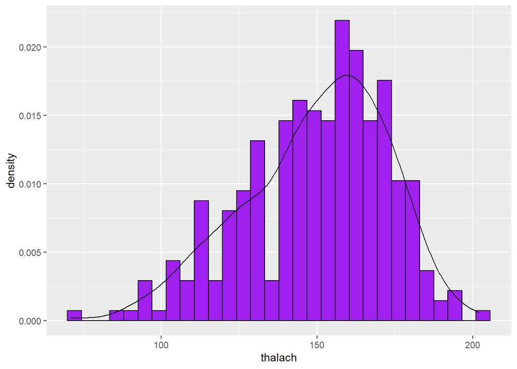

```r
ggplot(data=heart,aes(x=thalach))+geom_histogram(aes(y=..density..),color="Black", fill="Purple")+geom_density()
```

## 5.5 Pie Chart

```r
cp_group = heart %>% group_by(cp) %>% summarise(Adet=n())
```

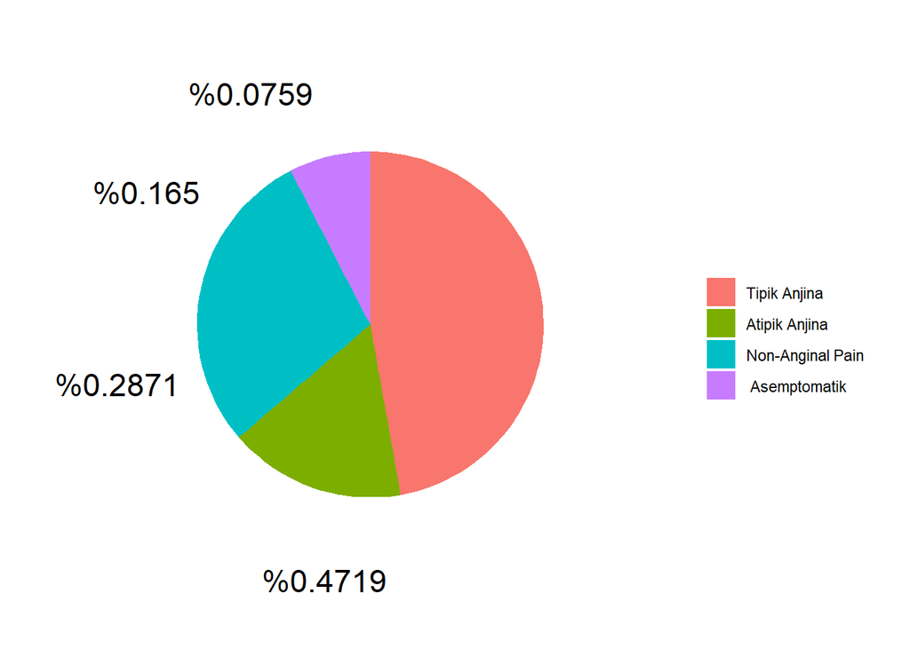

```r
cp_group$Oran=cp_group$Adet/303


ggplot(data=cp_group,aes(x="",y=Oran,fill=cp)) +
    geom_bar(stat="identity",width=1) +
    coord_polar("y",direction=-1) +
    #Temayı boş tut
    theme_void() +
    #Oy oranlarını ekle
    geom_text(aes(label = paste0("%",round(Oran,4)),x=2),size=6,angle=0) +
    #Lejant başlığını kaldır
    labs(fill="")
```

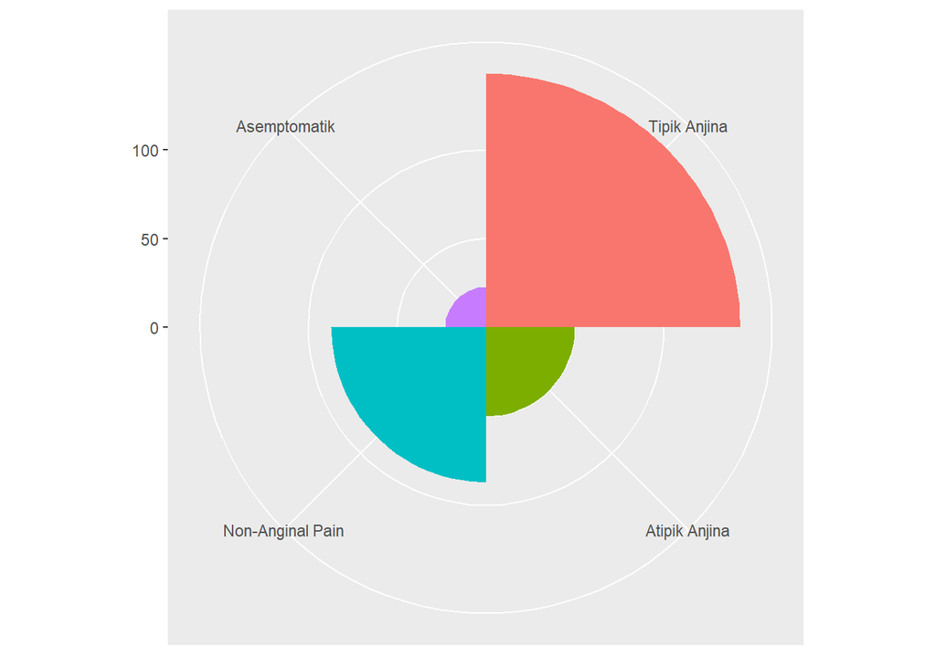

```r
ggplot(data = heart) +
  geom_bar(mapping = aes(x = cp, fill = cp), show.legend = FALSE, width = 1) +
  theme(aspect.ratio = 1) +
  labs(x = NULL, y = NULL)+
  coord_flip()+
  coord_polar()
```